# Recall performance for objects inside the rooms

# 1 Visual inspection of the data

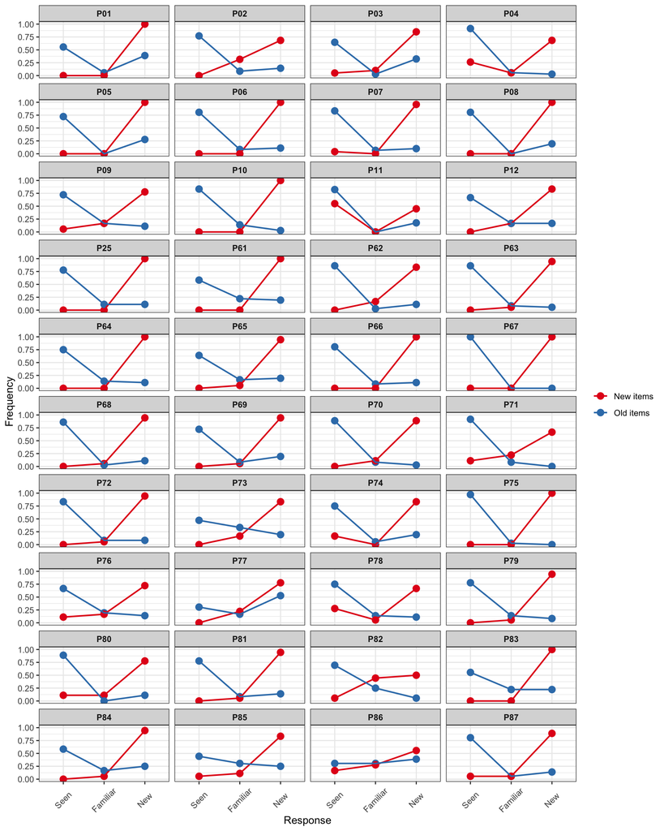

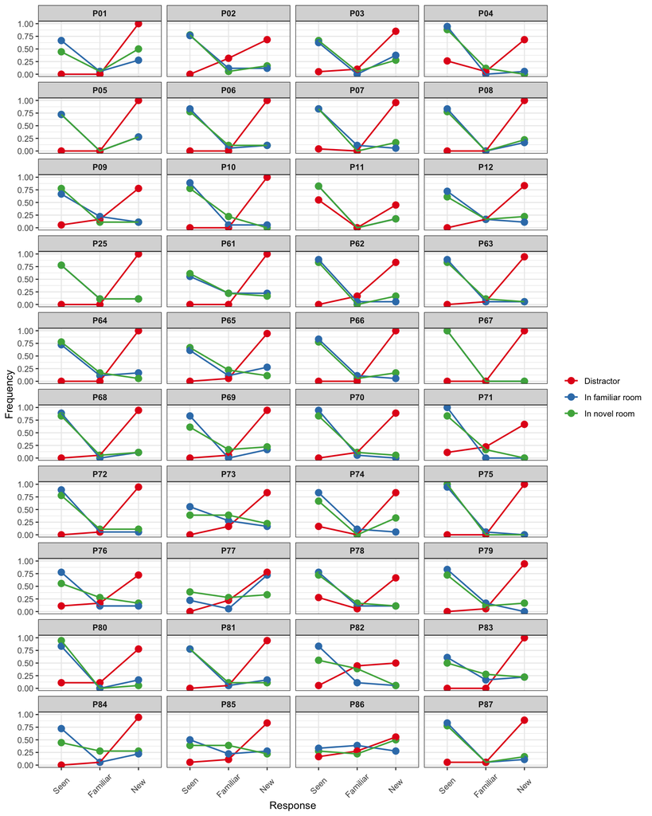

# 2 Novelty Benefits

## 2.1 Check the data

- **Is there any corrected hit rate < 0?**
  - There are 0 negative values.

## 2.2 Compare mean accuracy between *novel* and *familiar* rooms

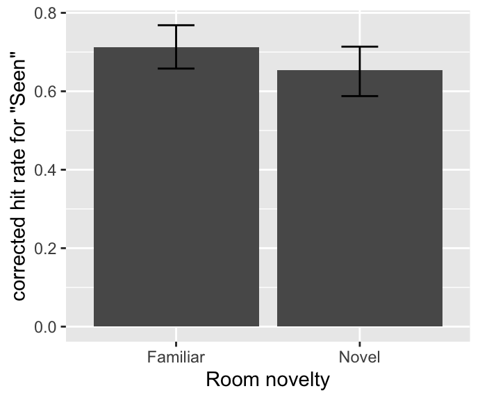

Figure1. Mean accuracy for item memory respectively for Familiar and Novel rooms.

```
##       Group      Mean        SD  N
## 1:    Novel 0.6531147 0.1981777 40
## 2: Familiar 0.7129554 0.1891087 40
```

```
##
##  Paired t-test
##
## data:  SAcc by Group
## t = 3.6203, df = 39, p-value = 0.0008362
## alternative hypothesis: true difference in means is not equal to 0
## 95 percent confidence interval:
##  0.02640735 0.09327402
## sample estimates:
## mean of the differences
##              0.05984069
```

## 2.3 Any difference between *Early* and *Later* object groups?

### 2.3.1 Check the data

- **Is there any corrected hit rate < 0?**
  - There are 0 negative values out of a total of 160 values.

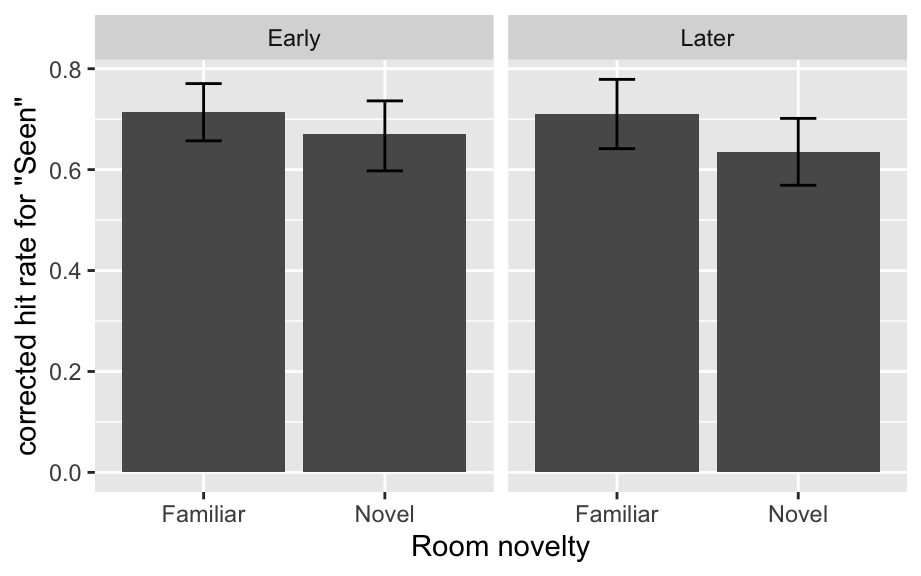

```
##       Group ObjOrdGrp      Mean        SD  N
## 1:    Novel     Early 0.6704349 0.2263053 40
## 2:    Novel     Later 0.6357127 0.2216787 40
## 3: Familiar     Later 0.7112088 0.2325430 40
## 4: Familiar     Early 0.7148794 0.1870703 40
```

```
## $ANOVA
##            Effect DFn DFd          F            p p<.05         ges
## 2           Group   1  39 13.2083924 0.0008030248     * 0.019100702
## 3       ObjOrdGrp   1  39  0.6294869 0.4323443538       0.001991263
## 4 Group:ObjOrdGrp   1  39  0.6165539 0.4370750714       0.001303450
```

# 3 Curiosity Enhancement

## 3.1 Check the data

### 3.1.1 Is there any corrected hit rate < 0?

#### 3.1.1.1 For the data per room

- There are 1 negative values out of a total of 239 values.

```
##    SubjectNo     Context    Group CurRating RoomOrder Duration SFHit SHit
## 1:       P86 StorageRoom Familiar         3    Second 86.98412   0.5    0
##       SrcHit   SFFalse    SFalse  SrcFalse      SFAcc       SAcc
## 1: 0.1666667 0.4444444 0.1666667 0.1111111 0.05555556 -0.1666667
##        SrcAcc
## 1: 0.05555556
```

#### 3.1.1.2 For the data per curiosity group

- There are 0 negative value for curiosity group (1 ~ 3 and 5 ~ 7) out of a total of 78 values.

#### 3.1.1.3 For the data per curiosity group (median)

- There are 0 negative value for curiosity group (median) out of a total of 79 values.

## 3.2 Mean accuracy of item memory as a function of curiosity rating

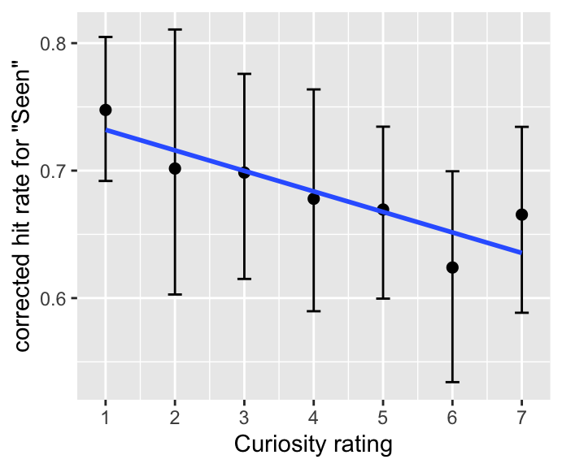

## 3.3 Testing the relationship between mean accuracy of item memory and curiosity rating

Build models with item memory accuracy as $y$ and examine effects of curiosity rating by including it into the model and then comparing the model fits.

- `baseline.rating` is the model with only an intercept, showing no change in item memory as a function of curiosity rating.
- `rating.intercept` is the model with $\small EncodingRating$ included, showing the effects of curiosity rating.
- `rating.slope` is the model allowing the slope (i.e., relationship between item memory and curiosity rating) varying across participants.

```
##                  Model df       AIC       BIC   logLik   Test  L.Ratio
## baseline.rating      1  3 -101.8051 -91.37573 53.90256
## rating.intercept     2  4 -108.7034 -94.79758 58.35172 1 vs 2 8.898314
## rating.slope         3  6 -104.6843 -83.82556 58.34217 2 vs 3 0.019091
##                  p-value
## baseline.rating
## rating.intercept  0.0029
## rating.slope      0.9905
```

```
## Linear mixed-effects model fit by maximum likelihood
##  Data: inside.hit.rate.per.room
##         AIC       BIC   logLik
##   -104.6843 -83.82556 58.34217
##
## Random effects:
##  Formula: ~1 + CurRating | SubjectNo
##  Structure: General positive-definite, Log-Cholesky parametrization
##             StdDev      Corr
## (Intercept) 0.169318374 (Intr)
## CurRating   0.001481275 0.044
## Residual    0.159692619
##
## Fixed effects: SAcc ~ CurRating
##                  Value  Std.Error  DF   t-value p-value
## (Intercept)  0.7481163 0.03600988 198 20.775308  0.0000
## CurRating   -0.0159861 0.00532934 198 -2.999644  0.0031
##  Correlation:
##           (Intr)
## CurRating -0.598
##
## Standardized Within-Group Residuals:
##        Min         Q1        Med         Q3        Max
## -2.7179957 -0.5858579  0.1236942  0.6109349  2.4403793
##
## Number of Observations: 239
## Number of Groups: 40
```

## 3.4 Check the curiosity groups

### 3.4.1 Separate the groups according to the rating

- *High*: curiosity rating > 4
- *Low*: curiosity rating < 4
- For curiosity rating = 4, discarded

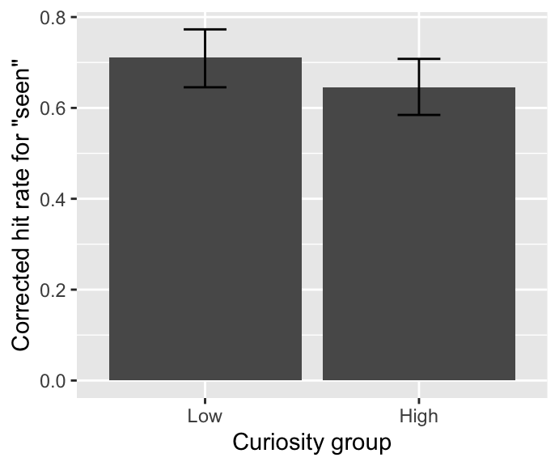

```
## Linear mixed-effects model fit by maximum likelihood
##  Data: inside.hit.rate.curiosity.group
##        AIC       BIC   logLik
##   -65.4875 -51.34725 38.74375
##
## Random effects:
##  Formula: ~1 + CurGrp | SubjectNo
##  Structure: General positive-definite, Log-Cholesky parametrization
##             StdDev     Corr
## (Intercept) 0.20451855 (Intr)
## CurGrpHigh  0.07110905 -0.27
## Residual    0.05542611
##
## Fixed effects: SAcc ~ CurGrp
##                  Value  Std.Error DF   t-value p-value
## (Intercept)  0.7033775 0.03415546 39 20.593411  0.0000
## CurGrpHigh  -0.0584634 0.01737650 37 -3.364507  0.0018
##  Correlation:
##            (Intr)
## CurGrpHigh -0.327
##
## Standardized Within-Group Residuals:
##         Min          Q1         Med          Q3         Max
## -1.44334699 -0.32147525  0.05336239  0.37277305  1.31024601
##
## Number of Observations: 78
## Number of Groups: 40
```

### 3.4.2 Curiosity groups and temporal order of the objects

#### 3.4.2.1 Check the data

- **Is there any corrected hit rate < 0?**
  - There are 1 negative values out of a total of 190 values.

```
##    SubjectNo CurGrp ObjOrdGrp SFHit SHit    SrcHit SFFalse SFalse
## 1:       P11   High     Later   0.5  0.5 0.3333333    0.55   0.55
##     SrcFalse SFAcc  SAcc SrcAcc
## 1: 0.1833333 -0.05 -0.05   0.15
```

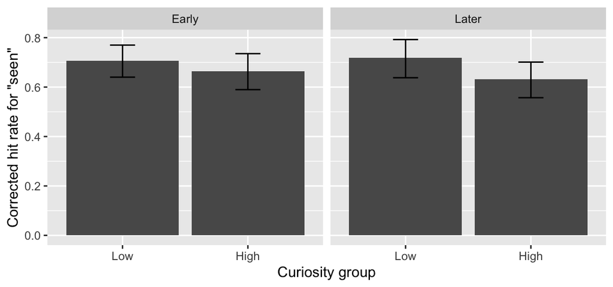

```
##    CurGrp ObjOrdGrp      Mean        SD  N
## 1:   High     Early 0.6637683 0.2353545 40
## 2:   High     Later 0.6309905 0.2422138 40
## 3:    Low     Later 0.7190982 0.2412999 38
## 4:   <NA>     Later 0.6684773 0.3025263 17
## 5:    Low     Early 0.7059403 0.2175777 38
## 6:   <NA>     Early 0.7221018 0.2541094 17
```

```
##           Model df       AIC       BIC   logLik   Test  L.Ratio p-value
## baseline      1  8 -69.57425 -45.17540 42.78713
## ord.model     2  9 -68.82602 -41.37732 43.41301 1 vs 2 1.251769  0.2632
## cur.model     3 10 -74.48942 -43.99086 47.24471 2 vs 3 7.663399  0.0056
## int.model     4 11 -73.90885 -40.36043 47.95442 3 vs 4 1.419427  0.2335
```

```
## Linear mixed-effects model fit by maximum likelihood
##  Data: inside.hit.rate.item.order.curiosity[!is.na(CurGrp)]
##         AIC       BIC   logLik
##   -73.90885 -40.36043 47.95442
##
## Random effects:
##  Formula: ~1 + CurGrp + ObjOrdGrp | SubjectNo
##  Structure: General positive-definite, Log-Cholesky parametrization
##                StdDev     Corr
## (Intercept)    0.18653602 (Intr) CrGrpH
## CurGrpHigh     0.04089901  0.009
## ObjOrdGrpLater 0.13836776 -0.006 -0.996
## Residual       0.11600454
##
## Fixed effects: SAcc ~ ObjOrdGrp + CurGrp + ObjOrdGrp:CurGrp
##                                Value  Std.Error  DF   t-value p-value
## (Intercept)                0.6988053 0.03555706 113 19.653065  0.0000
## ObjOrdGrpLater             0.0119031 0.03511542 113  0.338970  0.7353
## CurGrpHigh                -0.0350370 0.02756300 113 -1.271160  0.2063
## ObjOrdGrpLater:CurGrpHigh -0.0446809 0.03784726 113 -1.180558  0.2403
##  Correlation:
##                           (Intr) ObjOGL CrGrpH
## ObjOrdGrpLater            -0.296
## CurGrpHigh                -0.377  0.229
## ObjOrdGrpLater:CurGrpHigh  0.272 -0.558 -0.682
##
## Standardized Within-Group Residuals:
##         Min          Q1         Med          Q3         Max
## -2.87947548 -0.42302508  0.03536498  0.52889319  2.20842054
##
## Number of Observations: 156
## Number of Groups: 40
```

#### 3.4.2.2 *Post hoc*

```
##
##   Simultaneous Tests for General Linear Hypotheses
##
## Fit: lme.formula(fixed = SAcc ~ ObjOrdGrp + CurGrp + ObjOrdGrp:CurGrp,
##     data = inside.hit.rate.item.order.curiosity[!is.na(CurGrp)],
##     random = ~1 + CurGrp + ObjOrdGrp | SubjectNo, method = "ML",
##     na.action = na.exclude, control = list(msMaxIter = 500, opt = "optim",
##         msVerbose = FALSE))
##
## Linear Hypotheses:
##                          Estimate Std. Error z value Pr(>|z|)
## Early: High vs. Low == 0 -0.03504    0.02721  -1.288   0.1978
## Late:  High vs. Low == 0 -0.07972    0.02738  -2.911   0.0036 **
## ---
## Signif. codes:  0 '***' 0.001 '**' 0.01 '*' 0.05 '.' 0.1 ' ' 1
## (Adjusted p values reported -- none method)
```

### 3.4.3 Separate the groups according to the median rating of each participant

- *High*: curiosity rating > median of the participant
- *Low*: curiosity rating < median of the participant

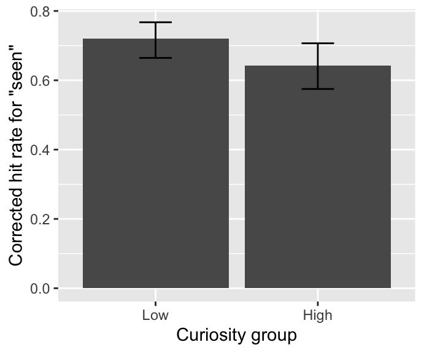

```
## Linear mixed-effects model fit by maximum likelihood
##  Data: inside.hit.rate.curiosity.group.median
##         AIC       BIC  logLik
##   -84.52661 -70.30992 48.2633
##
## Random effects:
##  Formula: ~1 + CurGrpMedian | SubjectNo
##  Structure: General positive-definite, Log-Cholesky parametrization
##                  StdDev     Corr
## (Intercept)      0.17003266 (Intr)
## CurGrpMedianHigh 0.06803204 0.273
## Residual         0.04878618
##
## Fixed effects: SAcc ~ CurGrpMedian
##                       Value  Std.Error DF   t-value p-value
## (Intercept)       0.7204349 0.02833018 39 25.429949       0
## CurGrpMedianHigh -0.0787009 0.01571534 38 -5.007903       0
##  Correlation:
##                  (Intr)
## CurGrpMedianHigh 0.045
##
## Standardized Within-Group Residuals:
##         Min          Q1         Med          Q3         Max
## -1.19772342 -0.33024646  0.06743736  0.39750150  1.15924707
##
## Number of Observations: 79
## Number of Groups: 40
```

#### 3.4.3.1 Curiosity groups and temporal order of the objects

##### 3.4.3.1.1 Check the data

```
##    SubjectNo CurGrpMedian ObjOrdGrp SFHit SHit    SrcHit SFFalse SFalse
## 1:       P11         High     Later   0.5  0.5 0.3333333    0.55   0.55
##     SrcFalse SFAcc  SAcc SrcAcc
## 1: 0.1833333 -0.05 -0.05   0.15
```

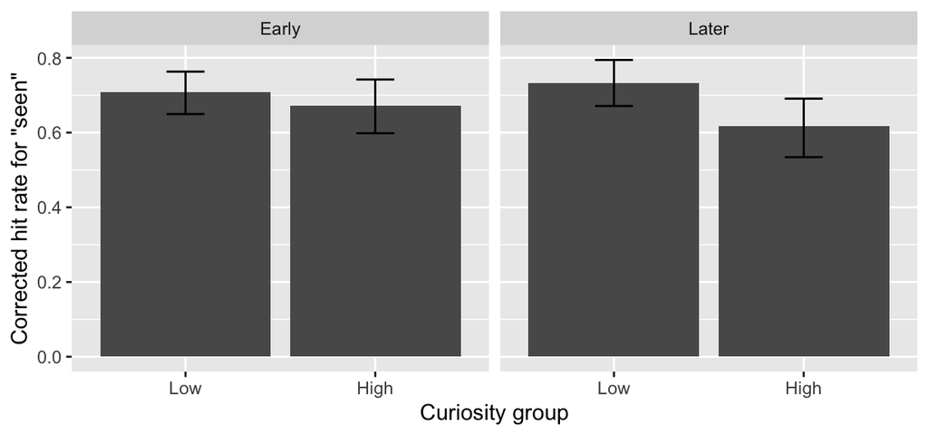

```
##    CurGrpMedian ObjOrdGrp      Mean        SD  N
## 1:         High     Early 0.6715999 0.2315399 39
## 2:         High     Later 0.6166142 0.2393254 39
## 3:          Low     Later 0.7335302 0.2176017 40
## 4:          Low     Early 0.7079349 0.1929949 40
```

```
##           Model df       AIC       BIC   logLik   Test   L.Ratio p-value
## baseline      1  8 -82.86410 -58.36334 49.43205
## ord.model     2  9 -81.38195 -53.81860 49.69098 1 vs 2  0.517850  0.4718
## cur.model     3 10 -92.72765 -62.10170 56.36382 2 vs 3 13.345694  0.0003
## int.model     4 11 -95.21279 -61.52424 58.60639 3 vs 4  4.485144  0.0342
```

```
## Linear mixed-effects model fit by maximum likelihood
##  Data: inside.hit.rate.item.order.curiosity.median
##         AIC       BIC   logLik
##   -95.21279 -61.52424 58.60639
##
## Random effects:
##  Formula: ~1 + CurGrpMedian + ObjOrdGrp | SubjectNo
##  Structure: General positive-definite, Log-Cholesky parametrization
##                  StdDev     Corr
## (Intercept)      0.15362742 (Intr) CrGrMH
## CurGrpMedianHigh 0.03645412  0.910
## ObjOrdGrpLater   0.09843214  0.007 -0.379
## Residual         0.11675666
##
## Fixed effects: SAcc ~ ObjOrdGrp + CurGrpMedian + ObjOrdGrp:CurGrpMedian
##                                      Value  Std.Error  DF   t-value
## (Intercept)                      0.7079349 0.03090332 115 22.908055
## ObjOrdGrpLater                   0.0255952 0.03078674 115  0.831372
## CurGrpMedianHigh                -0.0371597 0.02737127 115 -1.357617
## ObjOrdGrpLater:CurGrpMedianHigh -0.0797232 0.03769590 115 -2.114905
##                                 p-value
## (Intercept)                      0.0000
## ObjOrdGrpLater                   0.4075
## CurGrpMedianHigh                 0.1772
## ObjOrdGrpLater:CurGrpMedianHigh  0.0366
##  Correlation:
##                                 (Intr) ObjOGL CrGrMH
## ObjOrdGrpLater                  -0.365
## CurGrpMedianHigh                -0.259  0.374
## ObjOrdGrpLater:CurGrpMedianHigh  0.300 -0.603 -0.689
##
## Standardized Within-Group Residuals:
##        Min         Q1        Med         Q3        Max
## -2.0193030 -0.4810167  0.1106042  0.5694013  2.2852974
##
## Number of Observations: 158
## Number of Groups: 40
```

##### 3.4.3.1.2 *Post hoc*

```
##
##   Simultaneous Tests for General Linear Hypotheses
##
## Fit: lme.formula(fixed = SAcc ~ ObjOrdGrp + CurGrpMedian + ObjOrdGrp:CurGrpMedian,
##     data = inside.hit.rate.item.order.curiosity.median, random = ~1 +
##         CurGrpMedian + ObjOrdGrp | SubjectNo, method = "ML",
##     na.action = na.exclude, control = list(msMaxIter = 500, opt = "optim",
##         msVerbose = FALSE))
##
## Linear Hypotheses:
##                          Estimate Std. Error z value Pr(>|z|)
## Early: High vs. Low == 0 -0.03716    0.02702  -1.375    0.169
## Late:  High vs. Low == 0 -0.11688    0.02700  -4.328  1.5e-05 ***
## ---
## Signif. codes:  0 '***' 0.001 '**' 0.01 '*' 0.05 '.' 0.1 ' ' 1
## (Adjusted p values reported -- none method)
```

# 4 **Novelty** or **Curiosity**?

## 4.1 For Curiosity group splitted by score (*Low*: 1 ~ 3; *High*: 5 ~ 7)

### 4.1.1 Curiosity first, novelty next

```
##               Model df       AIC       BIC   logLik   Test  L.Ratio
## base.model        1  8 -85.66811 -58.66588 50.83405
## cur.scr.model     2  9 -91.12593 -60.74843 54.56297 1 vs 2 7.457829
## nov.scr.model     3 10 -89.14986 -55.39708 54.57493 2 vs 3 0.023926
##               p-value
## base.model
## cur.scr.model  0.0063
## nov.scr.model  0.8771
```

```
##                  Value  Std.Error  DF  t-value      p-value
## (Intercept) 0.64790799 0.03259454 175 19.87781 9.476119e-47
## CurGrpLow   0.06231802 0.02183900 175  2.85352 4.845544e-03
```

### 4.1.2 Novelty first, curiosity next

```
##               Model df       AIC       BIC   logLik   Test  L.Ratio
## base.model        1  8 -85.66811 -58.66588 50.83405
## nov.scr.model     2  9 -90.52473 -60.14722 54.26236 1 vs 2 6.856623
## cur.scr.model     3 10 -89.14986 -55.39708 54.57493 2 vs 3 0.625131
##               p-value
## base.model
## nov.scr.model  0.0088
## cur.scr.model  0.4291
```

```
## Linear mixed-effects model fit by maximum likelihood
##  Data: inside.hit.rate.per.room[!is.na(CurGrp)]
##         AIC       BIC   logLik
##   -89.14986 -55.39708 54.57493
##
## Random effects:
##  Formula: ~1 + CurGrp + Group | SubjectNo
##  Structure: General positive-definite, Log-Cholesky parametrization
##             StdDev      Corr
## (Intercept) 0.182471744 (Intr) CrGrpL
## CurGrpLow   0.001149365 -0.018
## GroupNovel  0.002143557  0.024  0.150
## Residual    0.154246709
##
## Fixed effects: SAcc ~ Group + CurGrp
##                  Value  Std.Error  DF   t-value p-value
## (Intercept)  0.6530176 0.04663111 174 14.003905  0.0000
## GroupNovel  -0.0056665 0.03687399 174 -0.153671  0.8780
## CurGrpLow    0.0575607 0.03791963 174  1.517965  0.1308
##  Correlation:
##            (Intr) GrpNvl
## GroupNovel -0.713
## CurGrpLow  -0.711  0.817
##
## Standardized Within-Group Residuals:
##        Min         Q1        Med         Q3        Max
## -2.8794577 -0.5834429  0.1410748  0.6330555  1.9970582
##
## Number of Observations: 216
## Number of Groups: 40
```

## 4.2 For Curiosity group splitted by individual medians

### 4.2.1 Curiosity first, novelty next

```
##              Model df        AIC       BIC   logLik   Test  L.Ratio
## base.model       1  8  -98.67666 -71.31238 57.33833
## cur.md.model     2  9 -111.04111 -80.25630 64.52056 1 vs 2 14.36445
## nov.md.model     3 10 -108.84457 -74.63922 64.42229 2 vs 3  0.19654
##              p-value
## base.model
## cur.md.model  0.0002
## nov.md.model  0.6575
```

### 4.2.2 Novelty first, curiosity next

```
##              Model df        AIC       BIC   logLik   Test   L.Ratio
## base.model       1  8  -98.67666 -71.31238 57.33833
## nov.md.model     2  9 -108.31411 -77.52930 63.15706 1 vs 2 11.637457
## cur.md.model     3 10 -108.84457 -74.63922 64.42229 2 vs 3  2.530457
##              p-value
## base.model
## nov.md.model  0.0006
## cur.md.model  0.1117
```

```
## Linear mixed-effects model fit by maximum likelihood
##  Data: inside.hit.rate.per.room[!is.na(CurGrpMedian)]
##         AIC       BIC   logLik
##   -108.8446 -74.63922 64.42229
##
## Random effects:
##  Formula: ~1 + CurGrpMedian + Group | SubjectNo
##  Structure: General positive-definite, Log-Cholesky parametrization
##                 StdDev      Corr
## (Intercept)     0.189262519 (Intr) CrGrML
## CurGrpMedianLow 0.036833205 -0.978
## GroupNovel      0.001512514  0.050 -0.034
## Residual        0.151031307
##
## Fixed effects: SAcc ~ Group + CurGrpMedian
##                      Value  Std.Error  DF   t-value p-value
## (Intercept)      0.6633136 0.04805676 184 13.802714  0.0000
## GroupNovel      -0.0222534 0.03748797 184 -0.593615  0.5535
## CurGrpMedianLow  0.0615378 0.03792555 184  1.622594  0.1064
##  Correlation:
##                 (Intr) GrpNvl
## GroupNovel      -0.716
## CurGrpMedianLow -0.806  0.830
##
## Standardized Within-Group Residuals:
##        Min         Q1        Med         Q3        Max
## -2.9252381 -0.6573739  0.1517235  0.6341248  2.0449438
##
## Number of Observations: 226
## Number of Groups: 40
```

## 4.3 For mean curiosity ratings for the *novel* and *familiar* rooms respectively

### 4.3.1 Curiosity first, novelty next

```r
basic <- lme(SAcc ~ 1, random = ~ 1 + Group|SubjectNo, data = inside.hit.rate.novelty.group, method = "ML", control = list(msMaxIter = 500, opt = "optim", msVerbose=FALSE), na.action = na.exclude)

cur.m <- update(basic, .~. + MeanCurRt)
nov.m <- update(cur.m, .~. + Group)

anova(basic, cur.m, nov.m)
```

```
##       Model df       AIC       BIC   logLik   Test   L.Ratio p-value
## basic     1  5 -68.72856 -56.81843 39.36428
## cur.m     2  6 -81.98742 -67.69526 46.99371 1 vs 2 15.258862  0.0001
## nov.m     3  7 -79.98824 -63.31405 46.99412 2 vs 3  0.000813  0.9773
```

```
##                   Value   Std.Error DF   t-value      p-value
## (Intercept)  0.76301630 0.032463709 39 23.503670 1.234368e-24
## MeanCurRt   -0.01972901 0.004648329 39 -4.244324 1.310080e-04
```

### 4.3.2 Novelty first, curiosity next

```r
nov.m <- update(basic, .~. + Group)
cur.m <- update(nov.m, .~. + MeanCurRt)

anova(basic, nov.m, cur.m)
```

```
##       Model df       AIC       BIC   logLik   Test   L.Ratio p-value
## basic     1  5 -68.72856 -56.81843 39.36428
## nov.m     2  6 -78.31782 -64.02566 45.15891 1 vs 2 11.589261  0.0007
## cur.m     3  7 -79.98824 -63.31405 46.99412 2 vs 3  3.670414  0.0554
```

```
##                    Value  Std.Error DF     t-value      p-value
## (Intercept)  0.763631534 0.03898227 39 19.58920076 8.729033e-22
## GroupNovel   0.000989453 0.03468497 38  0.02852686 9.773912e-01
## MeanCurRt   -0.019987072 0.01009987 38 -1.97894348 5.510267e-02
```

### 4.3.3 Testing mediation effect

```r
fit.1 <- lme(SAcc ~ Group, random = ~ 1 + Group|SubjectNo, data = inside.hit.rate.novelty.group, method = "ML")
summary(fit.1)
```

```
## Linear mixed-effects model fit by maximum likelihood
##  Data: inside.hit.rate.novelty.group
##         AIC       BIC   logLik
##   -78.31782 -64.02566 45.15891
##
## Random effects:
##  Formula: ~1 + Group | SubjectNo
##  Structure: General positive-definite, Log-Cholesky parametrization
##             StdDev     Corr
## (Intercept) 0.17888860 (Intr)
## GroupNovel  0.07015325 -0.06
## Residual    0.05354347
##
## Fixed effects: SAcc ~ Group
##                  Value  Std.Error DF   t-value p-value
## (Intercept)  0.7129554 0.02990070 39 23.844099   0e+00
## GroupNovel  -0.0598407 0.01652914 39 -3.620315   8e-04
##  Correlation:
##            (Intr)
## GroupNovel -0.188
##
## Standardized Within-Group Residuals:
##        Min         Q1        Med         Q3        Max
## -1.5734318 -0.2882859  0.0527427  0.3763709  1.0855523
##
## Number of Observations: 80
## Number of Groups: 40
```

```r
fit.2 <- lme(MeanCurRt ~ Group, random = ~ 1 + Group|SubjectNo, data = inside.hit.rate.novelty.group, method = "ML")
summary(fit.2)
```

```
## Linear mixed-effects model fit by maximum likelihood
##  Data: inside.hit.rate.novelty.group
##        AIC      BIC    logLik
##   225.5975 239.8897 -106.7988
##
## Random effects:
##  Formula: ~1 + Group | SubjectNo
##  Structure: General positive-definite, Log-Cholesky parametrization
##             StdDev    Corr
## (Intercept) 0.9688910 (Intr)
## GroupNovel  1.3840963 -0.886
## Residual    0.4498443
##
## Fixed effects: MeanCurRt ~ Group
##                Value Std.Error DF  t-value p-value
## (Intercept) 2.535447 0.1710533 39 14.82256       0
## GroupNovel  3.043474 0.2439232 39 12.47718       0
##  Correlation:
##            (Intr)
## GroupNovel -0.854
##
## Standardized Within-Group Residuals:
##         Min          Q1         Med          Q3         Max
## -1.35885358 -0.30620136  0.01067453  0.32299490  1.26490580
##
## Number of Observations: 80
## Number of Groups: 40
```

```r
fit.3 <- lme(SAcc ~ MeanCurRt + Group, random = ~ 1 + Group|SubjectNo, data = inside.hit.rate.novelty.group, method = "ML")
summary(fit.3)
```

```
## Linear mixed-effects model fit by maximum likelihood
##  Data: inside.hit.rate.novelty.group
##         AIC       BIC   logLik
##   -79.98824 -63.31405 46.99412
##
## Random effects:
##  Formula: ~1 + Group | SubjectNo
##  Structure: General positive-definite, Log-Cholesky parametrization
##             StdDev     Corr
## (Intercept) 0.17493791 (Intr)
## GroupNovel  0.06803667 0.065
## Residual    0.05153120
##
## Fixed effects: SAcc ~ MeanCurRt + Group
##                  Value  Std.Error DF   t-value p-value
## (Intercept)  0.7636316 0.03898226 39 19.589205  0.0000
## MeanCurRt   -0.0199871 0.01009987 38 -1.978945  0.0551
## GroupNovel   0.0009895 0.03468497 38  0.028528  0.9774
##  Correlation:
##            (Intr) MnCrRt
## MeanCurRt  -0.657
## GroupNovel  0.546 -0.886
##
## Standardized Within-Group Residuals:
##         Min          Q1         Med          Q3         Max
## -1.45443699 -0.33287947  0.05105598  0.41324735  1.07137149
##
## Number of Observations: 80
## Number of Groups: 40
```

```r
library(RMediation)
```

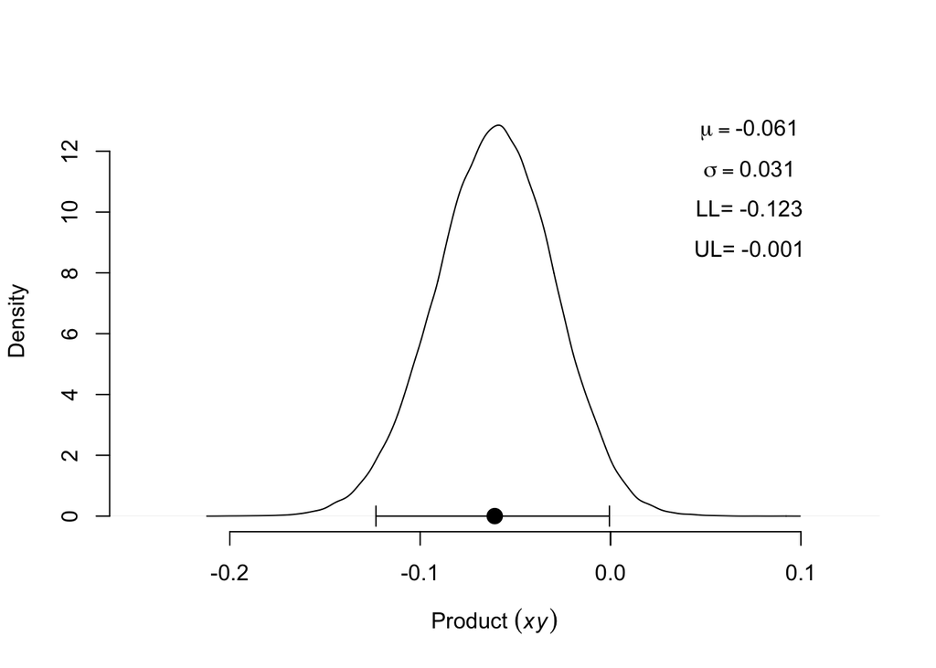

```
## $`97.5% CI`
## [1] -0.1232384278 -0.0005795615
##
## $Estimate
## [1] -0.06083018
##
## $SE
## [1] 0.03122027
```

```r
a = summary(fit.2)$tTable[2, 1]
se.a = summary(fit.2)$tTable[2,2]
b = summary(fit.3)$tTable[2,1]
se.b = summary(fit.3)$tTable[2,2]

medci(mu.x=a, mu.y=b, se.x=se.a, se.y=se.b, rho=0, alpha=.05, type="prodclin", plot=TRUE, plotCI=TRUE)
```